# temp_cleaned_notebook

## RAG Privacy Policy Simplifier

**Project type:** Proof-of-Concept (PoC)  
**Input:** fittiching Privacy policy URL online  
**Output:** Simplified rewrite in clear English  
**Main idea:** Use **RAG** to reduce hallucination and summarization and highlighting

## 1) Problem Statement

Privacy policies are tooo long and written in legal language. Most users dont read them fully or they misunderstand what data is collected, how it is used, and who it is shared with. Normal summarizers can also **hallucinate** or **drop important details**

## 2) Goal

Build a lightweight end-to-end **RAG pipeline** that rewrites (not invents) or omit privacy policy text into **clear, simple English** while preserving meaning and reducing hallucination risk. This is mainly to **prove the idea works** before heavy optimization. With focus **on only TikTok** as a PoC use case for simplifying.

## 3) Scope

**Included:**

- Fetch policy text from official URL
- Clean text (fix weird encoding chars)
- Chunking + embeddings + retrieval (Top-K)
- Rewrite with strict rules (no guessing)
- evalution

**Not included (for now):**

- Legal verification / lawyer review
- Perfect section-by-section formatting
- Multi-doc evaluation system (advanced scoring)
- Guarantee of 100% coverage

## **Model Development and Coding**

## Importing Libraries

```python
!pip -q install -U transformers accelerate bitsandbytes sentence-transformers lxml textstat matplotlib
!pip -q install pandas==2.2.2 requests==2.32.4

import os
import re
import math
import requests
import numpy as np
import pandas as pd
import matplotlib.pyplot as plt
import torch
import textstat

from bs4 import BeautifulSoup
from sentence_transformers import SentenceTransformer
from transformers import AutoTokenizer, AutoModelForCausalLM, BitsAndBytesConfig

device = "cuda" if torch.cuda.is_available() else "cpu"
print("Device:", device)
if device == "cuda":
    print("GPU:", torch.cuda.get_device_name(0))
```

```
     ━━━━━━━━━━━━━━━━━━━━━━━━━━━━━━━━━━━━━━━━ 52.8/52.8 kB 5.0 MB/s eta 0:00:00
   ━━━━━━━━━━━━━━━━━━━━━━━━━━━━━━━━━━━━━━━━ 59.1/59.1 MB 46.2 MB/s eta 0:00:00
   ━━━━━━━━━━━━━━━━━━━━━━━━━━━━━━━━━━━━━━━━ 176.6/176.6 kB 17.5 MB/s eta 0:00:00
   ━━━━━━━━━━━━━━━━━━━━━━━━━━━━━━━━━━━━━━━━ 8.7/8.7 MB 151.3 MB/s eta 0:00:00
   ━━━━━━━━━━━━━━━━━━━━━━━━━━━━━━━━━━━━━━━━ 2.1/2.1 MB 74.9 MB/s eta 0:00:00
Device: cuda
GPU: NVIDIA L4
```

## Secure HF Token + Project Configration

```python
from getpass import getpass

if not os.getenv("HF_TOKEN"):
    print("\nHF_TOKEN not found in environment.")
    print("Paste your HuggingFace token:")
    os.environ["HF_TOKEN"] = getpass("HF_TOKEN: ")

hf_token = os.getenv("HF_TOKEN", "")

print("HF_TOKEN check passed.")

POLICY_URLS = [
    "https://www.tiktok.com/legal/privacy-policy?lang=en"
]

RETRIEVAL_QUERY = "data collection, sharing, retention, rights, security, advertising, tracking"

# Chunking knobs
CHUNK_WORDS = 500  # after lots of trials this was the best threshould for the use case
CHUNK_OVERLAP = 80
MIN_CHUNK_WORDS = 120

# Retrieval knobs
TOP_K = 12  # this is after alot of trials i started with 6 but if you prefer more coverage, ok

# Models
EMBED_MODEL_NAME = "sentence-transformers/all-MiniLM-L6-v2"
GEN_MODEL_NAME   = "mistralai/Mistral-7B-Instruct-v0.2"

# Generator knobs
GEN_MAX_NEW_TOKENS = 1400 # to make it stable
```

```
HF_TOKEN not found in environment.
Paste your HuggingFace token:
HF_TOKEN: ··········
HF_TOKEN check passed.
```

## Fetching Polices + Generic cleaning

```python
def _normalize_whitespace(s: str) -> str:
    s = s.replace("\u00a0", " ")
    s = re.sub(r"[ \t]+", " ", s)
    s = re.sub(r"\n{3,}", "\n\n", s)
    return s.strip()

# This removes the unreadable symbols retrieved while reading the policies, which I observed after reviewing a number of them.
def fix_mojibake(s: str) -> str:
    return (s.replace("â", "'")
             .replace("â", '"')
             .replace("â", '"')
             .replace("â", "-")
             .replace("Â", " ")
             .strip())

def fetch_policy(url: str, timeout: int = 30) -> str:
    headers = {
        "User-Agent": "Mozilla/5.0",
        "Accept-Language": "en-US,en;q=0.9",
    }
    r = requests.get(url, headers=headers, timeout=timeout)
    if r.status_code != 200:
        preview = (r.text or "")[:200]
        raise RuntimeError(f"Fetch failed: {r.status_code}\nPreview:\n{preview}")

    soup = BeautifulSoup(r.text, "lxml")

    for tag in soup(["script", "style", "noscript"]):
        tag.decompose()

    main = soup.find("main") or soup.find("article")
    text = main.get_text("\n") if main else soup.get_text("\n")

    text = _normalize_whitespace(text)
    text = fix_mojibake(text)
    return text

def clean_text(raw: str) -> str:
    before = len(raw)
    lines = [ln.strip() for ln in raw.splitlines()]
    lines = [ln for ln in lines if len(ln) > 2]
    cleaned = "\n".join(lines)
    cleaned = _normalize_whitespace(cleaned)
    cleaned = fix_mojibake(cleaned)
    after = len(cleaned)
    print(f"Cleaned chars: {after} (removed ~{max(0, before-after)} chars)")
    return cleaned

# Will be used to display the result in consle for faster viewing
def preview_head_tail(text: str, n: int = 1200) -> None:
    print("\n" + "="*70)
    print(f"TEXT STATS | chars: {len(text)} | words: {len(text.split())}")
    print("="*70)
    print("\n[HEAD PREVIEW]\n")
    print(text[:n])
    print("\n" + "-"*70)
    print("\n[TAIL PREVIEW]\n")
    print(text[-n:])
    print("\n" + "="*70 + "\n")

policies = []
for url in POLICY_URLS:
    print("\nFetching:", url)
    raw = fetch_policy(url)
    text = clean_text(raw)

    if len(text) < 20000:
        print("WARNING: Policy text looks too short (<20k chars). It may be incomplete")

    preview_head_tail(text, n=1200)
    policies.append({"url": url, "text": text})

# Optional manual override: because after alot of trials many of polcies are pages are protected from fitiching
MANUAL_POLICY_TEXT = ""
if MANUAL_POLICY_TEXT.strip():
    policies = [{"url": "MANUAL_INPUT", "text": clean_text(MANUAL_POLICY_TEXT)}]
    preview_head_tail(policies[0]["text"], n=1200)
```

```
Fetching: https://www.tiktok.com/legal/privacy-policy?lang=en
Cleaned chars: 50903 (removed ~103 chars)

======================================================================
TEXT STATS | chars: 50903 | words: 8237
======================================================================

[HEAD PREVIEW]

Privacy Policy | TikTok
Other regions
Privacy Policy
Last updated: July 8, 2025
Welcome to TikTok. This Privacy Policy applies to TikTok services, which include TikTok apps, websites, software and related services (the "Platform"). The Platform is provided and controlled by TikTok Pte. Ltd., with its registered address at 1 Raffles Quay, #26-10, South Tower, Singapore 048583 ("…
We are committed to protecting and respecting your privacy. This Privacy Policy explains how we collect, use, share, and otherwise process the personal information of users, and other individuals. If you do not agree with this policy, you should not use the Platform.
What information we collect
We may collect the following information about you:
Information You Provide
Your account information.
You give us information when you register on the Platform, including your username, password, date of birth (where applicable), email address and/or telephone number, information you disclose in your user account, and your photograph or profile video.
User content.
We process the content you generate on the Platform, including photographs, audios and videos you upload or create, comments, hashta

----------------------------------------------------------------------

[TAIL PREVIEW]

u are below 16 years old or under guardianship:
you must obtain approval from your parent(s) or legal guardian(s); and
your parent(s) or legal guardian(s) are responsible for: (i) all your actions in connection with your access to and use of the Platform; (ii) your compliance with this policy; and (iii) ensuring that any of your participation in the Platform will not, in any event, result in any violation of applica…
If you do not have consent from your parent(s) or legal guardian(s) and your parent(s) or legal guardian(s) is not willing to open the account under their name, you must cease accessing the Platform if you are not at least 16 years of age.
Nothing in this Privacy Policy shall be construed as a waiver or limitation to statutory consumer rights that cannot be contractually limited under applicable laws.
Other Jurisdictions
In jurisdictions where the national or official language is not English, the version of the TikTok Privacy Policy in your local language may set out additional terms specific to your jurisdiction. Please also refer to the version of this Privacy Policy in your local language for further information.

======================================================================
```

I pulled the TikTok policy text from the link and cleaned the messy lines. I checked the **head** and **tail** to make sure the page is not empty or cut. It looks full length (big **word count**), so i can move to chunking now.

## Chunking

split policy into overlapping chunks

```python
def chunk_text(text: str, chunk_words: int = 500, overlap_words: int = 80, min_words: int = 120) -> list[str]:
    words = text.split()
    chunks = []
    i = 0
    step = max(1, chunk_words - overlap_words)

    while i < len(words):
        chunk_words_list = words[i:i + chunk_words]
        chunk = " ".join(chunk_words_list).strip()
        if chunk and len(chunk_words_list) >= min_words:
            chunks.append(chunk)
        i += step

    return chunks

def chunk_stats(chunks: list[str]) -> None:
    sizes = [len(c.split()) for c in chunks]
    print(f"Chunks: {len(chunks)} | words min/avg/max: {min(sizes)}/{sum(sizes)//len(sizes)}/{max(sizes)}")

def preview_chunks(chunks: list[str], take: int = 2, chars: int = 800) -> None:
    take = min(take, len(chunks))
    for idx in range(take):
        print("\n" + "="*70)
        print(f"CHUNK #{idx} | words: {len(chunks[idx].split())}")
        print("="*70)
        print(chunks[idx][:chars])
        print("\n" + "="*70)

for p in policies:
    chunks = chunk_text(p["text"], CHUNK_WORDS, CHUNK_OVERLAP, MIN_CHUNK_WORDS)

    if len(chunks) < 6:
        print("WARNING: Few chunks (<6). !!!!")

    chunk_stats(chunks)
    preview_chunks(chunks, take= 2, chars= 800)
    p["chunks"] = chunks
```

```
Chunks: 20 | words min/avg/max: 257/487/500

======================================================================
CHUNK #0 | words: 500
======================================================================
Privacy Policy | TikTok Other regions Privacy Policy Last updated: July 8, 2025 Welcome to TikTok. This Privacy Policy applies to TikTok services, which include TikTok apps, websites, software and related services (the "Platform"). The Platform is provided and controlled by TikTok Pte. Ltd., with it…

======================================================================

======================================================================
CHUNK #1 | words: 500
======================================================================
in your device's clipboard , with your permission. For example, if you choose to initiate content sharing with a third-party platform, or choose to paste content from the clipboard into the Platform, we access this information stored in your clipboard in order to fulfill your request. Purchase infor…

======================================================================
```

look i chunked the policy into ~500-word parts with a small **overlap** so the edges dont cut meanings ended up with **20 chunks**, most of them near the same size, so retrieval should be stable i think the small last chunk is normal,

## Embeddings + Retrieval

```python
embedder = SentenceTransformer(EMBED_MODEL_NAME)

def embed_chunks(chunks: list[str]) -> tuple[np.ndarray, list[str]]:
    chunks_clean = [c.strip() for c in chunks if c and c.strip()]
    emb = embedder.encode(chunks_clean, normalize_embeddings=True, show_progress_bar=False)
    return np.array(emb), chunks_clean

def retrieve_topk(chunks: list[str], chunk_emb: np.ndarray, query: str, top_k: int):
    q_emb = embedder.encode([query], normalize_embeddings=True, show_progress_bar=False)[0]
    scores = chunk_emb @ q_emb
    k = min(top_k, len(scores))
    top_idx = np.argsort(-scores)[:k].tolist()
    return top_idx, [chunks[i] for i in top_idx], [float(scores[i]) for i in top_idx]

def preview_retrieved(indices, retrieved, scores, chars: int = 800):
    print("\nRetrieved chunk indices:", indices)
    for j, (idx, txt, sc) in enumerate(zip(indices, retrieved, scores)):
        print("\n" + "=" * 70)
        print(f"RETRIEVED #{j} | chunk={idx} | score={sc:.4f} | words={len(txt.split())}")
        print("=" * 70)
        print(txt[:chars])
        print("\n" + "=" * 70)

for p in policies:
    p["chunk_emb"], p["chunks_clean"] = embed_chunks(p["chunks"])

    print(f'\n[RAG] url={p.get("url","")} | chunks={len(p["chunks_clean"])} | TOP_K={TOP_K}')
    idxs, retrieved, scores = retrieve_topk(p["chunks_clean"], p["chunk_emb"], RETRIEVAL_QUERY, TOP_K)

    preview_retrieved(idxs, retrieved, scores, chars=800)

    p["retrieved_idxs"] = idxs
    p["retrieved_texts"] = retrieved
    p["retrieved_scores"] = scores
```

```
README.md: 0.00B [00:00, ?B/s]
```

```
vocab.txt: 0.00B [00:00, ?B/s]
```

```
tokenizer.json: 0.00B [00:00, ?B/s]
```

```
[RAG] url=https://www.tiktok.com/legal/privacy-policy?lang=en | chunks=20 | TOP_K=12

Retrieved chunk indices: [6, 4, 2, 5, 7, 14, 1, 3, 19, 15, 17, 0]

======================================================================
RETRIEVED #0 | chunk=6 | score=0.5450 | words=500
======================================================================
providers of content moderation services to ensure that the Platform is a safe and enjoyable place and service providers that assist us in marketing the Platform. Payment processors and transaction fulfillment providers : If you choose to buy Coins or conduct other payment related transactions, we w…

======================================================================

======================================================================
RETRIEVED #1 | chunk=4 | score=0.5183 | words=500
======================================================================
services, including sharing your information with sellers, payment and transaction fulfillment providers, and other service providers in order to process your orders. To personalise the content you see when you use the Platform. For example, we may provide you with services based on the country sett…

======================================================================

======================================================================
RETRIEVED #2 | chunk=2 | score=0.5166 | words=500
======================================================================
log-in from multiple devices, we use your information such as your device IDs and user ID to identify your activity across devices. We may also associate you with information collected from devices other than those you use to log-in to the Platform. Location Information. We collect information about…

======================================================================

======================================================================
RETRIEVED #3 | chunk=5 | score=0.5049 | words=500
======================================================================
approach to keeping our community safe. To facilitate research conducted by independent researchers that meets certain criteria. To verify your identity or age. To communicate with you, including to notify you about changes in our services. To announce you as a winner of our contests or promotions i…

======================================================================

======================================================================
RETRIEVED #4 | chunk=7 | score=0.5021 | words=500
======================================================================
can change who can see a video each time you upload a video. Alternatively, you can change your profile to default private by changing your settings to 'Private Account' in "Manage my account" settings. Sale, Merger or Other Business Transactions We may also disclose your information to third partie…

======================================================================

======================================================================
```

[output cut: 32 more lines]

```
======================================================================

======================================================================
RETRIEVED #10 | chunk=17 | score=0.3924 | words=500
======================================================================
Privacy Policy. Where we store your personal data. Your personal data may be transferred from Russia to Singapore and stored in that location, outside of the country where you live. Public profiles. We rely on your consent to public distribution of personal data, when your account settings are 'Publ…

======================================================================

======================================================================
RETRIEVED #11 | chunk=0 | score=0.3884 | words=500
======================================================================
Privacy Policy | TikTok Other regions Privacy Policy Last updated: July 8, 2025 Welcome to TikTok. This Privacy Policy applies to TikTok services, which include TikTok apps, websites, software and related services (the "Platform"). The Platform is provided and controlled by TikTok Pte. Ltd., with it…

======================================================================
```

look i ran embeddings on the **20 chunks** and pulled **TOP_K=12** top results look real tbh: sharing, ads/analytics, location, security, transfers, contacts, purchases, and rights

now i can feed these retrieved chunks into the generator

## Load Generator Model (Mistral 7B Instruct, 4-bit)

Load tokenizer + model

4-bit quantization to fit GPU

```python
bnb_config = BitsAndBytesConfig(
    load_in_4bit=True,
    bnb_4bit_quant_type="nf4",
    bnb_4bit_use_double_quant=True,
    bnb_4bit_compute_dtype=torch.float16,
)

tokenizer = AutoTokenizer.from_pretrained(GEN_MODEL_NAME, token=hf_token, use_fast=True)
if tokenizer.pad_token_id is None:
    tokenizer.pad_token = tokenizer.eos_token

model = AutoModelForCausalLM.from_pretrained(
    GEN_MODEL_NAME,
    token=hf_token,
    quantization_config=bnb_config,
    device_map="auto",
)
model.eval()

print("Loaded generator:", GEN_MODEL_NAME)
print("pad_token_id:", tokenizer.pad_token_id)
```

```
tokenizer_config.json: 0.00B [00:00, ?B/s]
```

```
tokenizer.json: 0.00B [00:00, ?B/s]
```

```
model.safetensors.index.json: 0.00B [00:00, ?B/s]
```

```
Loaded generator: mistralai/Mistral-7B-Instruct-v0.2
pad_token_id: 2
```

I loaded the **generator model** (Mistral 7B Instruct) and it finished without errors So now the model is ready

## Rewrite/Simplify

```python
def build_context_from_idxs(all_chunks: list[str], idxs: list[int], max_chunks: int = 11, per_chunk_chars: int = 1200) -> str:
    uniq = sorted(set(idxs))[:max_chunks]
    chosen = []
    for i in uniq:
        c = (all_chunks[i] or "").strip()
        c = fix_mojibake(c)
        if c:
            chosen.append(c[:per_chunk_chars])
    return "\n\n".join(chosen)

def cleanup_output(text: str) -> str:
    t = fix_mojibake(text.replace("\r", "")).strip()
    t = re.sub(r"\n{3,}", "\n\n", t)
    t = re.sub(r"\.{2,}", ".", t)      # remove ".. .. .."
    t = t.replace("<", "").replace(">", "")
    return t.strip()

def generate_rewrite(context: str, max_new_tokens: int = 1400) -> str:
    user_prompt = (
        "Task: Rewrite this privacy policy in clear, simple English for an average user.\n\n"
        "Strict rules:\n"
        "- Preserve the meaning. Do not add, guess, or invent anything.\n"
        "- Do not merge different parts in a way that changes meaning.\n"
        "- If something is unclear or not explicitly stated, omit it.\n"
        "- Use short paragraphs only. No bullet lists. No numbering.\n"
        "- Avoid unusual symbols. Use normal punctuation only.\n"
        "- Do not repeat the same idea again and again. If you start repeating, stop.\n\n"
        "Text:\n"
        f"{context}\n"
    )

    messages = [{"role": "user", "content": user_prompt}]
    prompt = tokenizer.apply_chat_template(messages, tokenize=False, add_generation_prompt=True) if hasattr(tokenizer, "apply_chat_template") else user_prompt

    inputs = tokenizer(prompt, return_tensors="pt", truncation=True, max_length=5500)
    input_len = inputs["input_ids"].shape[-1]
    inputs = {k: v.to(model.device) for k, v in inputs.items()}

    with torch.no_grad():
        out = model.generate(
            **inputs,
            max_new_tokens=max_new_tokens,
            do_sample=False,
            repetition_penalty=1.12, # After trying different penalty values, this worked the best for the use case
            no_repeat_ngram_size=8,
            pad_token_id=tokenizer.eos_token_id,
        )

    gen_tokens = out[0][input_len:]
    return cleanup_output(tokenizer.decode(gen_tokens, skip_special_tokens=True))

TOP_K_FOR_GEN = min(11, TOP_K)

for p in policies:
    context = build_context_from_idxs(
        all_chunks=p["chunks"],
        idxs=p["retrieved_idxs"],
        max_chunks=TOP_K_FOR_GEN,
        per_chunk_chars=1200
    )

    print(f"\n[GEN] url={p['url']} | context_chunks={min(TOP_K_FOR_GEN, len(set(p['retrieved_idxs'])))}")
    simplified = generate_rewrite(context, max_new_tokens=GEN_MAX_NEW_TOKENS).strip()

    simplified += (
        "\n\n---\n"
        "Note (experimental): This summary is for learning/testing purposes only and may contain mistakes. "
        "The official and legally binding text is the original privacy policy.\n"
        "Ahmed Wadee Moustafa"
    )

    p["simplified"] = simplified

    print("\n" + "="*90)
    print("SIMPLIFIED OUTPUT")
    print("="*90)
    print(simplified)
    print("="*90 + "\n")
```

```
[GEN] url=https://www.tiktok.com/legal/privacy-policy?lang=en | context_chunks=11

==========================================================================================
SIMPLIFIED OUTPUT
==========================================================================================
Welcome to TikTok! Here's how we handle your information on our apps, websites, and related services:

We collect several types of information:

* Information you give us: This includes your account details like username, password, email address, phone number, and profile picture. Also, the content you create, such as photos, videos, and comments.
* Device contacts: If you choose to sync your phone or social network contacts, we access and collect names, phone numbers, and email address to match them with existing TikTok users.
* Location information: We gather your approximate location from your SIM card and IP address. With your permission, precise location data like GPS is also collected.
* Image and audio information: We analyze videos, images, and audio in your content to enhance special effects, moderate content, classify demographics, recommend content, and provide personalized ads.

We use this information to:

* Personalize content and services
* Send promotional materials via email or instant messages
* Improve and develop the Platform
* Measure ad effectiveness and deliver targeted ads
* Support social functions, such as connecting with friends
* Ensure safety and security
* Conduct research and verify identity or age
* Communicate with you about changes to our services
* Announce contest winners and send prizes
* Enforce our policies and protect our rights

We share your information with:

* Business partners: For content moderation, marketing, and social networking services.
* Payment processors and transaction fulfillment partners: To process payments and transactions.
* Analytics providers: To help us optimize and improve the Platform.
* Advertisers, advertising networks, publishers, and measurement partners: To serve ads and help advertisers understand their audience.
* Sellers, payment and transaction fulfillment providers: To process your orders when you shop on the Platform.

Your personal data may be transferred to countries like Singapore, Malaysia, Ireland, and the US for storage and processing. By using TikTok, you consent to these data sharing and transfer activities.

You have the right to access, update, delete, or restrict the processing of your personal data. If you have concerns or questions, please contact us.

---
Note (experimental): This summary is for learning/testing purposes only and may contain mistakes. The official and legally binding text is the original privacy policy.
Ahmed Wadee Moustafa
==========================================================================================
```

I ran the **trial summary** and as a normal user Id rate it as ( proof, not perfect) The **good part** is it matched the real chunks: **location (approx + GPS)**, **image/audio analysis**, **sharing with ads/analytics/payment**, and **data transfer** (Singapore/Malaysia/Ireland/US) The **bad part** is small **over-talk / semi-hallucsination**: it used **bullet points** even tho we said “short paragrphs only”, and it wrote “you **consent**” which can be risky if the text didnt say it cleary Also some lines are **too general** like “business partners for social networking”, feels broad and not super pinned to the exact wording

## Evaluation

|  | Policy | Version | FKGL | GunningFog | SMOG | Words | Chars |
| --- | --- | --- | --- | --- | --- | --- | --- |
| 0 | https://www.tiktok.com/legal/privacy-policy?la... | Before | 14.822747 | 17.65520 | 15.787659 | 8237 | 50903 |
| 1 | https://www.tiktok.com/legal/privacy-policy?la... | After | 13.476316 | 16.49218 | 14.924445 | 374 | 2473 |

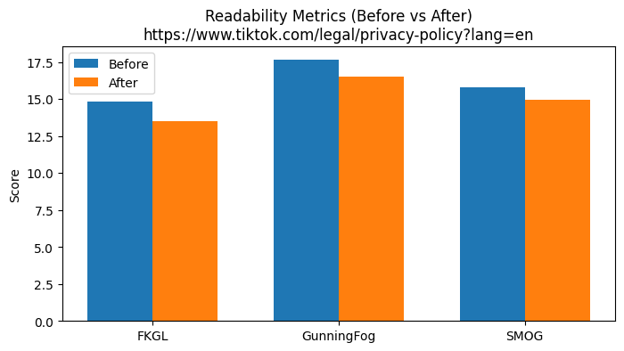

```python
def compute_scores(text: str) -> dict:
    return {
        "FKGL": float(textstat.flesch_kincaid_grade(text)),
        "GunningFog": float(textstat.gunning_fog(text)),
        "SMOG": float(textstat.smog_index(text)),
        "Words": int(len(text.split())),
        "Chars": int(len(text)),
    }

rows = []
for p in policies:
    before = p["text"]
    after = p["simplified"]

    s_before = compute_scores(before)
    s_after = compute_scores(after)

    rows.append({"Policy": p["url"], "Version": "Before", **s_before})
    rows.append({"Policy": p["url"], "Version": "After", **s_after})

df = pd.DataFrame(rows)
display(df)

metrics = ["FKGL", "GunningFog", "SMOG"]

for policy_url in df["Policy"].unique():
    sub = df[df["Policy"] == policy_url].set_index("Version")
    before_vals = [sub.loc["Before", m] for m in metrics]
    after_vals = [sub.loc["After", m] for m in metrics]

    x = np.arange(len(metrics))
    w = 0.35

    plt.figure(figsize=(8, 4))
    plt.bar(x - w/2, before_vals, width=w, label="Before")
    plt.bar(x + w/2, after_vals, width=w, label="After")
    plt.xticks(x, metrics)
    plt.ylabel("Score")
    plt.title(f"Readability Metrics (Before vs After)\n{policy_url}")
    plt.legend()
    plt.show()
```

I checked the **scores table** and its clear the output is waaay shorter than the real policy The original is **8237 words**, but the rewrite is only **374 words**, so it’s more like a tiny summary not a full simplifed policy Readability got a bit better (**FKGL / Fog / SMOG** drop), but it’s still kinda high, so the language is still “legal-ish” So for now it’s ok as a **trial proof**, but later I need either **more tokens** or a **chunk-by-chunk rewrite** or even more maybe even paid models and gpu power if I want more lenght

```python
# =========================
# Method 2 (OpenAI) — Full Policy Simplification (rewrite, NOT a short summary)
# Goal: keep ALL meaning + details, but rewrite in very simple English.
#
# Why chunk-by-chunk?
# - One-shot on the full policy can hit context limits or silently truncate.
# - Chunking keeps coverage stable.
# =========================

!pip -q install -U openai
from openai import OpenAI
if not os.getenv("OPENAI_API_KEY"):
    os.environ["OPENAI_API_KEY"] = getpass("OPENAI_API_KEY: ")

client = OpenAI()

avail = {m.id for m in client.models.list().data}
PREF  = ["gpt-5.2-pro","gpt-5.2","gpt-5","gpt-4.1","gpt-4o","gpt-4o-mini"]
MODEL = next((m for m in PREF if m in avail), None)
if not MODEL:
    raise RuntimeError("No preferred model available (billing/access).")

MAX_OUT = 1400

PROMPT = (
    "You are a detailed and precise legal language simplifier.\n"
    "Rewrite the policy text below in VERY simple English (A1 level max).\n"
    "Preserve ALL legal meaning and ALL details. Do NOT turn it into a short summary.\n"
    "Strict rules:\n"
    "- Do not add, guess, or invent anything.\n"
    "- Do not omit details.\n"
    "- Do not mix different parts in a way that changes meaning.\n"
    "- Keep the original order as much as possible.\n"
    "- No bullet points. No numbering.\n"
    "- Avoid weird symbols or anything that looks like code.\n"
    "- Use short sentences and short paragraphs.\n"
    "- If a legal term is needed to keep meaning, keep it and explain it simply.\n\n"
    "TEXT:\n{chunk}"
)

def _rw(chunk: str) -> str:
    r = client.responses.create(
        model=MODEL,
        max_output_tokens=MAX_OUT,
        input=[{"role":"user","content":PROMPT.format(chunk=chunk)}],
    )
    return (r.output_text or "").strip()

def _print_head_mid_tail(title: str, txt: str, head=2000, mid=2000, tail=2000):
    print("\n" + "="*90)
    print(f"{title} (head)")
    print("="*90)
    print(txt[:head])

    m = len(txt)//2
    print("\n" + "-"*90)
    print(f"{title} (middle)")
    print("-"*90)
    print(txt[max(0, m-mid//2): m+mid//2])

    print("\n" + "-"*90)
    print(f"{title} (tail)")
    print("-"*90)
    print(txt[-tail:])

for p in policies:
    chunks = p.get("chunks_clean") or p.get("chunks") or chunk_text(
        p["text"], CHUNK_WORDS, CHUNK_OVERLAP, MIN_CHUNK_WORDS
    )

    p["simplified_openai_full"] = "\n\n".join(
        _rw(c) for c in chunks if c and c.strip()
    ).strip()

    # BEFORE vs AFTER (head + middle + tail)
    _print_head_mid_tail("BEFORE", p["text"])
    _print_head_mid_tail("AFTER",  p["simplified_openai_full"])

    # metrics table (kept as-is)
    df = pd.DataFrame([
        {"Policy": p["url"], "Version": "Before", **compute_scores(p["text"])},
        {"Policy": p["url"], "Version": "After_RAG_Small", **compute_scores(p.get("simplified",""))},
        {"Policy": p["url"], "Version": "After_OpenAI_Full", **compute_scores(p["simplified_openai_full"])}
    ])
    display(df)

    print("MODEL:", MODEL)
    print("words before:", len(p["text"].split()))
    print("words rag_small:", len(p.get("simplified","").split()))
    print("words openai_full:", len(p["simplified_openai_full"].split()))
```

```
   ━━━━━━━━━━━━━━━━━━━━━━━━━━━━━━━━━━━━━━━━ 1.1/1.1 MB 66.0 MB/s eta 0:00:00
OPENAI_API_KEY: ··········

==========================================================================================
BEFORE (head)
==========================================================================================
Privacy Policy | TikTok
Other regions
Privacy Policy
Last updated: July 8, 2025
Welcome to TikTok. This Privacy Policy applies to TikTok services, which include TikTok apps, websites, software and related services (the "Platform"). The Platform is provided and controlled by TikTok Pte. Ltd., with its registered address at 1 Raffles Quay, #26-10, South Tower, Singapore 048583 ("…
We are committed to protecting and respecting your privacy. This Privacy Policy explains how we collect, use, share, and otherwise process the personal information of users, and other individuals. If you do not agree with this policy, you should not use the Platform.
What information we collect
We may collect the following information about you:
Information You Provide
Your account information.
You give us information when you register on the Platform, including your username, password, date of birth (where applicable), email address and/or telephone number, information you disclose in your user account, and your photograph or profile video.
User content.
We process the content you generate on the Platform, including photographs, audios and videos you upload or create, comments, hashtags, feedback, reviews, and livestreams you make, and the associated metadata, such as when, where, and by whom the content was created ("User Content"). Even if you are…
Messages.
We collect information you provide when you compose, send, or receive messages through the Platform's messaging functionalities and the associated

------------------------------------------------------------------------------------------
BEFORE (middle)
------------------------------------------------------------------------------------------
rms of Service, Community Guidelines, or other conditions or policies, we may remove your account from the Platform or User Content from public view immediately, but may keep other information about you to process the violation.
Information relating to children and teens
TikTok is not directed at children under the age of 13. In certain cases this age may be higher due to local regulatory requirements, please see your local supplemental terms for more information. If you believe that there is a user who is below this minimum age, please contact us at
https://www.tiktok.com/legal/report/privacy
If you are a parent or guardian, our
Guardian's Guide
contains information and resources to help you understand the Platform and the tools and controls you can use.
Privacy Policy update
We may update this Privacy Policy from time to time. When we update the Privacy Policy, we will notify you by updating the "Last Updated" date at the top of this policy and posting the new Privacy Policy or providing any other notice required by applicable law. Your continued access to or use of the…
Contact
If you have questions, comments, complaints or requests regarding this Privacy Policy, please contact us at:
https://www.tiktok.com/legal/report/privacy
Please also see the supplemental terms below on whether a local representative or local contact is available for your country.
We will endeavour to deal with your request as soon as possible. This is without prejudice to your right to make a complaint with a relevant data protection authority, where applicable.
Supplemental Terms - Jurisdiction-Specific
```

[output cut: 109 more lines]

```
In that case, your parent or parents, or your legal guardian or guardians, are responsible for all your actions that are connected to your access to the Platform and your use of the Platform.

They are also responsible for your following this policy.

They are also responsible for making sure that your participation in the Platform will not, in any event, cause any violation of applicable laws and rules about child protections.

If you do not have consent from your parent or parents, or your legal guardian or guardians, and your parent or parents or your legal guardian or guardians do not want to open the account under their own name, you must stop accessing the Platform if you are not at least 16 years old.

Nothing in this Privacy Policy is a waiver or a limitation of statutory consumer rights that cannot be limited by contract under applicable laws. Waiver means giving up a right. Limitation means making a right smaller. Statutory consumer rights means rights the law gives to consumers. Contract means…

Other jurisdictions.

In places where the national or official language is not English, the TikTok Privacy Policy in your local language may have extra terms that are only for your place.

Please also look at the version of this Privacy Policy in your local language for more information.
```

|  | Policy | Version | FKGL | GunningFog | SMOG | Words | Chars |
| --- | --- | --- | --- | --- | --- | --- | --- |
| 0 | https://www.tiktok.com/legal/privacy-policy?la... | Before | 14.822747 | 17.655200 | 15.787659 | 8237 | 50903 |
| 1 | https://www.tiktok.com/legal/privacy-policy?la... | After_RAG_Small | 13.476316 | 16.492180 | 14.924445 | 374 | 2473 |
| 2 | https://www.tiktok.com/legal/privacy-policy?la... | After_OpenAI_Full | 8.160506 | 10.455271 | 10.788214 | 13413 | 79597 |

```
MODEL: gpt-5.2-pro
words before: 8237
words rag_small: 374
words openai_full: 13413
```

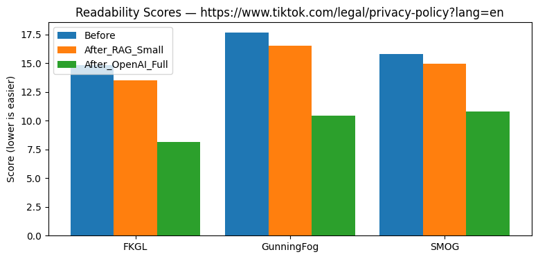

```python
# ONE graph only (same style: 3 metrics, 3 versions)
    metrics = ["FKGL", "GunningFog", "SMOG"]
    sub = df.set_index("Version")

    before_vals = [sub.loc["Before", m] for m in metrics]
    rag_vals    = [sub.loc["After_RAG_Small", m] for m in metrics]
    full_vals   = [sub.loc["After_OpenAI_Full", m] for m in metrics]

    x = np.arange(len(metrics))
    w = 0.28

    plt.figure(figsize=(9, 4))
    plt.bar(x - w, before_vals, width=w, label="Before")
    plt.bar(x,     rag_vals,    width=w, label="After_RAG_Small")
    plt.bar(x + w, full_vals,   width=w, label="After_OpenAI_Full")
    plt.xticks(x, metrics)
    plt.ylabel("Score (lower is easier)")
    plt.title(f"Readability Scores — {p['url']}")
    plt.savefig(f"sample_data/readability_scores.png", dpi=200, bbox_inches="tight")
    plt.legend()
    plt.show()
```

## Conclusion (what the results really mean)

I can now say this PoC worked in the way i actually needed, not just “some output”. The original TikTok policy is about **8237 words**, and the reading level was crazy high (**FKGL ~14.82**, **Fog ~17.66**). So even if a normal user tries, they will miss stuff or get bored fast, because the language is legal and dense.

When i used the Top-K RAG path, the output was only **374 words**. Thats not real “simplification”, thats more like a **small summary** of a few important areas. It can be useful for a fast view (like data sharing, ads, location, transfers), but it does not cover the full policy, so i cant claim it solves the real problem alone.

I also did the eye check (head / middle / tail) and the flow looks consistent. The rewrite kept the same idea order and didnt look like random invented paragraphs. So for this PoC, the best logic is: i use chunk-rewrite as the main method for the **full simplified policy**, and i keep Top-K retrieval as a second method only for **quick risk highlights** or “where to look first”, not as a replacment for full simplifcation.

```python
os.makedirs("sample_data", exist_ok=True)

for i,p in enumerate(policies,1):
    open(f"sample_data/policy_{i}_before.txt","w",encoding="utf-8").write(p["text"])
    open(f"sample_data/policy_{i}_rag_small.txt","w",encoding="utf-8").write(p.get("simplified",""))
    open(f"sample_data/policy_{i}_openai_full.txt","w",encoding="utf-8").write(p.get("simplified_openai_full",""))

print("saved txt files -> sample_data/")
```

```
saved txt files -> sample_data/
```

## Wrap-up

I finished the main run and the results look stable.

- **Model used (OpenAI):** gpt-5.2-pro
- **Policy size (original):** ~8237 words
- **Runtime (this run):** ~24 minutes for 1 policy (end-to-end, chunk rewrite)
- **Cost note:** this method makes many model calls (one per chunk), so scaling to more policies will **cost more** and will likely need a bigger budget (and maybe stronger compute / batching) to stay fast.

### Next step if i scale to more policies

If i run this on 5 policies, i should expect:

- higher total cost (more chunks = more calls)
- longer runtime (unless i parallelize or reduce per-chunk output)